# Advanced tidyverse

10 May 2018

## Tidy data

## It is not just about data frames

- "Tidy data" isn't just cleaned data. You should think about the structure of the data and the resulting objects.
- In research, we often perform the **same** algorithms/functions to data with **similar** structures, using different **parameter values**.
- The traditional way of doing this is to have `original.data`, `original.data.param1.algo1`, `original.data.param1.algo2` as separate objects.

```r
ols.Setosa = lm(Petal.Length ~ .,
                data = iris %>%
                  filter(Species == "setosa") %>%
                  select(-Species))
ols.Versicolor = lm(Petal.Length ~ .,
                    data = iris %>%
                      filter(Species == "versicolor") %>%
                      select(-Species))
ols.Virginica = lm(Petal.Length ~ .,
                   data = iris %>%
                     filter(Species == "virginica") %>%
                     select(-Species))

ols.Setosa$coefficients
```

```
##  (Intercept) Sepal.Length  Sepal.Width  Petal.Width
##   0.86546731   0.11605588  -0.02865363   0.46252684
```

```r
ols.Versicolor$coefficients
```

```
##  (Intercept) Sepal.Length  Sepal.Width  Petal.Width
##    0.1650588    0.4358623   -0.1068495    1.3602079
```

```r
ols.Virginica$coefficients
```

```
##  (Intercept) Sepal.Length  Sepal.Width  Petal.Width
##   0.46502707   0.74297175  -0.08225447   0.21564651
```

```r
# robustLm.Length = lmrob(Petal.Length ~ Sepal.Length, data = iris)
```

## `for` loop vs `list`

- Of course, if you know the structure of your data well eonugh, you could do looping so you shouldn't type everything out. But this could be slow.
- If you are a bit fancy, you could use `lapply` and `mapply` functions. However, as the complexity of your pipeline grows, you need to have better naming conventions and ever longer list of objects to keep tract of. And let's don't forget, matching between objects can be a nightmare!

```r
olsSpecies = c()
for(i in unique(iris$Species)){
  olsSpecies[[i]] =  lm(Petal.Length ~ .,
                        data = iris %>%
                          filter(Species == i) %>%
                          select(-Species))

}
olsSpecies
```

```
## $setosa
##
## Call:
## lm(formula = Petal.Length ~ ., data = iris %>% filter(Species ==
##     i) %>% select(-Species))
##
## Coefficients:
##  (Intercept)  Sepal.Length   Sepal.Width   Petal.Width
##      0.86547       0.11606      -0.02865       0.46253
##
##
## $versicolor
##
## Call:
## lm(formula = Petal.Length ~ ., data = iris %>% filter(Species ==
##     i) %>% select(-Species))
##
## Coefficients:
##  (Intercept)  Sepal.Length   Sepal.Width   Petal.Width
##       0.1651        0.4359       -0.1068        1.3602
##
##
## $virginica
##
## Call:
## lm(formula = Petal.Length ~ ., data = iris %>% filter(Species ==
##     i) %>% select(-Species))
##
## Coefficients:
##  (Intercept)  Sepal.Length   Sepal.Width   Petal.Width
##      0.46503       0.74297      -0.08225       0.21565
```

## Think about the structure

## First step: all we need is to split the data into 3 parts

- `tidyr::nest` is a powerful function for spliting data.
- Here is where `tibble` is become tremendously powerful.

```r
irisNest = iris %>%
  dplyr::group_by(Species) %>%
  tidyr::nest()

irisNest
```

```
## # A tibble: 3 x 2
##   Species    data
##   <fct>      <list>
## 1 setosa     <tibble [50 × 4]>
## 2 versicolor <tibble [50 × 4]>
## 3 virginica  <tibble [50 × 4]>
```

## Second step: fit a linear model to `irisNest$data` column

- We could use `lapply` here. But sometimes, it isn't the best option due to cumbersome notations.
- `purrr::map` is equivalent to `lapply`.

```r
olsModels = purrr::map(
  .x = irisNest$data,
  .f = ~ lm(Petal.Length ~ .,
            data = .x)
)

olsModels
```

```
## [[1]]
##
## Call:
## lm(formula = Petal.Length ~ ., data = .x)
##
## Coefficients:
##  (Intercept)  Sepal.Length   Sepal.Width   Petal.Width
##      0.86547       0.11606      -0.02865       0.46253
##
##
## [[2]]
##
## Call:
## lm(formula = Petal.Length ~ ., data = .x)
##
## Coefficients:
##  (Intercept)  Sepal.Length   Sepal.Width   Petal.Width
##       0.1651        0.4359       -0.1068        1.3602
##
##
## [[3]]
##
## Call:
## lm(formula = Petal.Length ~ ., data = .x)
##
## Coefficients:
##  (Intercept)  Sepal.Length   Sepal.Width   Petal.Width
##      0.46503       0.74297      -0.08225       0.21565
```

## Why use `purrr::map`?

- `lapply` and `mapply` are fine. But they offer less control over the returned data types and they don't have a consistent argument input.
- `purrr::map` has consistent notations with its generalisation of `purrr::map2`.
- `purrr` is also smart!

```r
lapply(olsModels, function(x){x$coefficients})
```

```
## [[1]]
##  (Intercept) Sepal.Length  Sepal.Width  Petal.Width
##   0.86546731   0.11605588  -0.02865363   0.46252684
##
## [[2]]
##  (Intercept) Sepal.Length  Sepal.Width  Petal.Width
##    0.1650588    0.4358623   -0.1068495    1.3602079
##
## [[3]]
##  (Intercept) Sepal.Length  Sepal.Width  Petal.Width
##   0.46502707   0.74297175  -0.08225447   0.21564651
```

```r
purrr::map(olsModels, "coefficients")
```

```
## [[1]]
##  (Intercept) Sepal.Length  Sepal.Width  Petal.Width
##   0.86546731   0.11605588  -0.02865363   0.46252684
##
## [[2]]
##  (Intercept) Sepal.Length  Sepal.Width  Petal.Width
##    0.1650588    0.4358623   -0.1068495    1.3602079
##
## [[3]]
##  (Intercept) Sepal.Length  Sepal.Width  Petal.Width
##   0.46502707   0.74297175  -0.08225447   0.21564651
```

```r
purrr::map_dbl(olsModels, stats::AIC)
```

```
## [1] -32.006620   1.590133  21.099269
```

## Put this all together, you have a very powerful framework to manage your data

## Each column of a tibble is a list

```r
rlmModels = purrr::map(
  .x = irisNest$data,
  .f = ~ MASS::rlm(Petal.Length ~ .,
                   data = .x))

irisModels = irisNest %>%
  mutate(
    olsModels = olsModels,
    rlmModels = rlmModels
  )

irisModels
```

```
## # A tibble: 3 x 4
##   Species    data              olsModels rlmModels
##   <fct>      <list>            <list>    <list>
## 1 setosa     <tibble [50 × 4]> <S3: lm>  <S3: rlm>
## 2 versicolor <tibble [50 × 4]> <S3: lm>  <S3: rlm>
## 3 virginica  <tibble [50 × 4]> <S3: lm>  <S3: rlm>
```

## And the columns can keep growing

```r
irisCorrelations = irisModels %>%
  mutate(
    olsModels_fitted = purrr::map(olsModels, "fitted.values"),
    rlmModels_fitted = purrr::map(rlmModels, "fitted.values"),
    cor_ols_rlm = map2_dbl(
      .x = olsModels_fitted,
      .y = rlmModels_fitted,
      .f = cor)
  )

irisCorrelations
```

```
## # A tibble: 3 x 7
##   Species  data      olsModels rlmModels olsModels_fitted rlmModels_fitted
##   <fct>    <list>    <list>    <list>    <list>           <list>
## 1 setosa   <tibble … <S3: lm>  <S3: rlm> <dbl [50]>       <dbl [50]>
## 2 versico… <tibble … <S3: lm>  <S3: rlm> <dbl [50]>       <dbl [50]>
## 3 virgini… <tibble … <S3: lm>  <S3: rlm> <dbl [50]>       <dbl [50]>
## # ... with 1 more variable: cor_ols_rlm <dbl>
```

## Example: PCA on `iris1` data

```r
iris.pca = prcomp(iris[,-5])$x
## We only want the PCs in our explorations

pca.tibble = tibble(
  Species = list(iris$Species),
  pcaData = list(iris.pca),
  k = 1:4
)

## We start with the data, and a set of different values of parameters
pca.tibble
```

```
## # A tibble: 4 x 3
##   Species     pcaData             k
##   <list>      <list>          <int>
## 1 <fct [150]> <dbl [150 × 4]>     1
## 2 <fct [150]> <dbl [150 × 4]>     2
## 3 <fct [150]> <dbl [150 × 4]>     3
## 4 <fct [150]> <dbl [150 × 4]>     4
```

## Example: performing kmeans with various k

```r
kmeans.tibble = mutate(pca.tibble,
                       pca_kmeans = purrr::map2(
                         .x = pcaData,
                         .y = k,
                         .f = ~ kmeans(x = .x, centers = .y)$cluster)
)
kmeans.tibble
```

```
## # A tibble: 4 x 4
##   Species     pcaData             k pca_kmeans
##   <list>      <list>          <int> <list>
## 1 <fct [150]> <dbl [150 × 4]>     1 <int [150]>
## 2 <fct [150]> <dbl [150 × 4]>     2 <int [150]>
## 3 <fct [150]> <dbl [150 × 4]>     3 <int [150]>
## 4 <fct [150]> <dbl [150 × 4]>     4 <int [150]>
```

## Example: visualisating kmeans clustering on iris data

```r
datavis.tibble = mutate(
  kmeans.tibble,
  visData = map2(.x = pca_kmeans,
                 .y = pcaData,
                 .f = ~ data.frame(
                   cluster = .x,
                   .y)),
  visData2 = map2(.x = visData,
                  .y = Species,
                  .f = ~ data.frame(
                    .x,
                    Species = .y
                  )),
  plots = map(.x = visData2,
              .f = ~ ggplot(.x) +
                geom_point(aes(x = PC1,
                               y = PC2,
                               colour = as.factor(cluster))) +
                facet_grid(cluster~Species) +
                theme(legend.position = "bottom")
  )
)
datavis.tibble %>% print(width = Inf)
```

```
## # A tibble: 4 x 7
##   Species     pcaData             k pca_kmeans  visData
##   <list>      <list>          <int> <list>      <list>
## 1 <fct [150]> <dbl [150 × 4]>     1 <int [150]> <data.frame [150 × 5]>
## 2 <fct [150]> <dbl [150 × 4]>     2 <int [150]> <data.frame [150 × 5]>
## 3 <fct [150]> <dbl [150 × 4]>     3 <int [150]> <data.frame [150 × 5]>
## 4 <fct [150]> <dbl [150 × 4]>     4 <int [150]> <data.frame [150 × 5]>
##   visData2               plots
##   <list>                 <list>
## 1 <data.frame [150 × 6]> <S3: gg>
## 2 <data.frame [150 × 6]> <S3: gg>
## 3 <data.frame [150 × 6]> <S3: gg>
## 4 <data.frame [150 × 6]> <S3: gg>
```

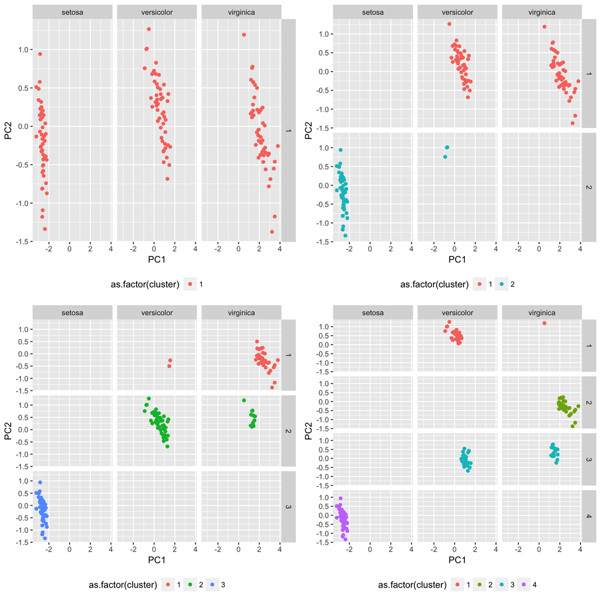

```r
# datavis.tibble$plots
do.call(gridExtra::arrangeGrob, datavis.tibble$plots) %>% plot
```

## Final advice

## Final advice

- Some of these tools are very advanced in terms of notations and programming practice.
- You should pick up small snipets of code here and there first before building a framework straight the way.
- E.g. As much as I enjoy using `purrr::map`, I still use `lapply` in some cases. I don't code everything in `tibble` either, only when the structure of the data gets too complex.